# Homework 3

Kinga Frańczak

# Preparation

## Loading Packages

```r
library(DALEX)
library(tidyverse)
library(caret)
library(ranger)
library(dplyr)
library(DALEXtra)
library(gbm)
```

## Loading Data Frame

```r
insurance <- read.csv("insurance.csv")
head(insurance)
```

```
##   age    sex    bmi children smoker    region   charges
## 1  19 female 27.900        0    yes southwest 16884.924
## 2  18   male 33.770        1     no southeast  1725.552
## 3  28   male 33.000        3     no southeast  4449.462
## 4  33   male 22.705        0     no northwest 21984.471
## 5  32   male 28.880        0     no northwest  3866.855
## 6  31 female 25.740        0     no southeast  3756.622
```

## Preparing Data Set

Categorical variables `sex`, `smoker` and `region` were change from character to factor to prepare data for use of gbm model.

```r
insurance <- as.data.frame(unclass(insurance),
                       stringsAsFactors = TRUE)
str(insurance)
```

```
## 'data.frame':    1338 obs. of  7 variables:
##  $ age     : int  19 18 28 33 32 31 46 37 37 60 ...
##  $ sex     : Factor w/ 2 levels "female","male": 1 2 2 2 2 1 1 1 2 1 ...
##  $ bmi     : num  27.9 33.8 33 22.7 28.9 ...
##  $ children: int  0 1 3 0 0 0 1 3 2 0 ...
##  $ smoker  : Factor w/ 2 levels "no","yes": 2 1 1 1 1 1 1 1 1 1 ...
##  $ region  : Factor w/ 4 levels "northeast","northwest",..: 4 3 3 2 2 3 3 2 1 2 ...
##  $ charges : num  16885 1726 4449 21984 3867 ...
```

## Splitting Data into Training Set and Test Set

```r
set.seed(42)

index <- createDataPartition(insurance$charges, p = 0.8, list = FALSE)
train <- insurance[index,]
test  <- insurance[-index,]
```

## Creating Models

Three model are used for predictions:

- Linear Regression
- Random Forest
- gbm

```r
lr <- lm(charges ~., data = train)
```

```r
rf <- ranger(charges ~., data = train)
```

```r
gbm <- gbm(charges ~., data = train, distribution = "gaussian")
```

## Comparison of Models’ Performance

```r
explainer_lr  <- DALEX::explain(model = lr,
                                data = test[,-7],
                                y = test$charges,
                                type = "regression",
                                label = "linear regression")

explainer_rf  <- DALEX::explain(model = rf,
                                 data = test[,-7],
                                 y = test$charges,
                                 type = "regression",
                                 label = "random forest")

explainer_gbm <- DALEX::explain(model = gbm,
                                data = test[,-7],
                                y = test$charges,
                                type = "regression",
                                label = "gbm")
```

```r
model_performance(explainer_lr)
```

```
## Measures for:  regression
## mse        : 40567253
## rmse       : 6369.243
## r2         : 0.7194076
## mad        : 2649.212
##
## Residuals:
##          0%         10%         20%         30%         40%         50%
## -10926.7763  -5689.2821  -3358.5071  -2370.6540  -1422.0796   -735.0541
##         60%         70%         80%         90%        100%
##   -178.0439   1022.9081   3499.2890   7497.6915  30107.4691
```

```r
model_performance(explainer_rf)
```

```
## Measures for:  regression
## mse        : 28197510
## rmse       : 5310.133
## r2         : 0.8049657
## mad        : 1679.242
##
## Residuals:
##         0%        10%        20%        30%        40%        50%        60%
## -6614.6681 -2803.6363 -2303.7717 -1825.1075 -1594.2630 -1286.7512  -956.6080
##        70%        80%        90%       100%
##  -360.9151   367.2018  5994.4389 26536.1841
```

```r
model_performance(explainer_gbm)
```

```
## Measures for:  regression
## mse        : 40243845
## rmse       : 6343.804
## r2         : 0.7216445
## mad        : 3044.147
##
## Residuals:
##          0%         10%         20%         30%         40%         50%
## -12700.8247  -5512.7078  -4059.8746  -3087.4025  -1978.1178   -243.9620
##         60%         70%         80%         90%        100%
##    501.7271   1175.7154   2348.7217   7869.6451  30358.8662
```

Linear Regression model and gbm model have similar values of rmse and r2. Random Forest model has the lowest rmse value and the highest r2 value among three models presented above.

# 1. Choosing Observation and Calculating Predictions

```r
observation1 <- test[13, ]
observation1
```

```
##    age    sex  bmi children smoker    region  charges
## 73  53 female 28.1        3     no southwest 11741.73
```

```r
pred_lr <- predict(lr, observation1[ ,-7])
pred_rf <- predict(rf, observation1[ ,-7])
pred_gbm <- predict(gbm, observation1[ ,-7])
```

```r
predictions <- c(pred_lr[[1]], pred_rf$predictions, pred_gbm)
models <- c("linear regression", "random forest", "gbm")
difference <- abs(predictions - observation1$charges)
results <- data.frame(Model = models, Prediction = predictions, Difference = difference)

results
```

```
##               Model Prediction Difference
## 1 linear regression   11786.89   45.16089
## 2     random forest   12809.05 1067.32498
## 3               gbm   11196.80  544.92365
```

Linear Regression model’s prediction was the most accurate for observation nr 1.

# 2. Creating Ceteris Paribus Profiles

```r
cp_lr <- predict_profile(explainer = explainer_lr,
                         new_observation = observation1)
cp_rf <- predict_profile(explainer = explainer_rf,
                         new_observation = observation1)
cp_gbm <- predict_profile(explainer = explainer_gbm,
                         new_observation = observation1)
```

# 3. Ceteris Paribus Profiles for Different Models

## `age` Variable

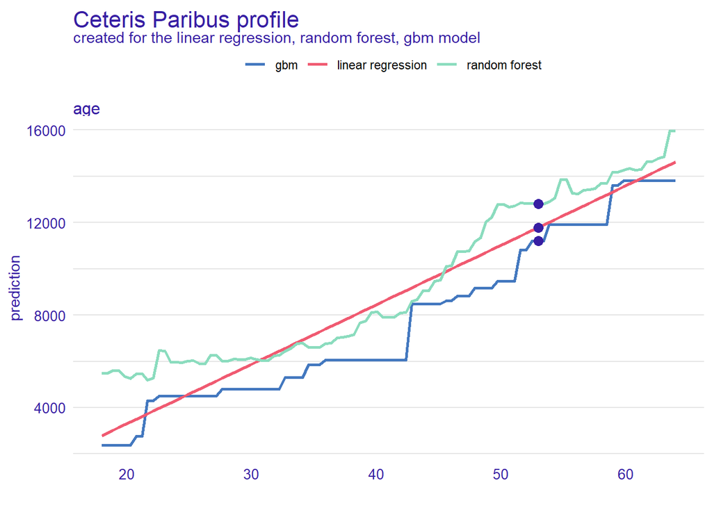

```r
plot(cp_lr, cp_rf, cp_gbm, variables = "age")
```

## `sex` Variable

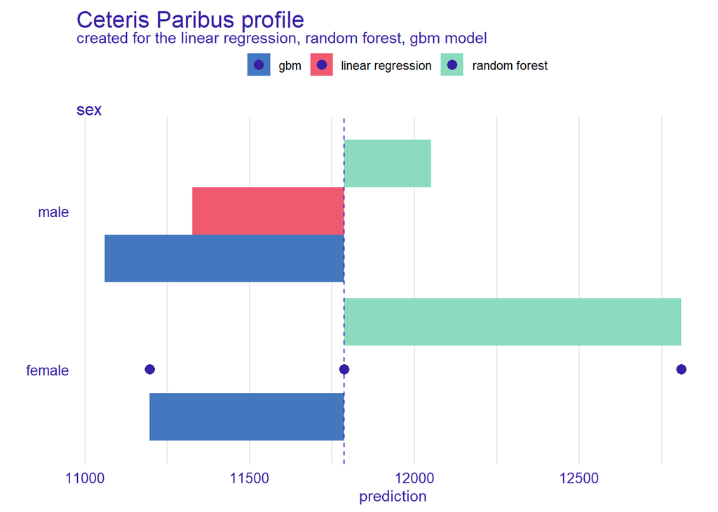

```r
plot(cp_lr, cp_rf, cp_gbm, variables = "sex", variable_type = "categorical", categorical_type = "bars")
```

## `bmi` Variable

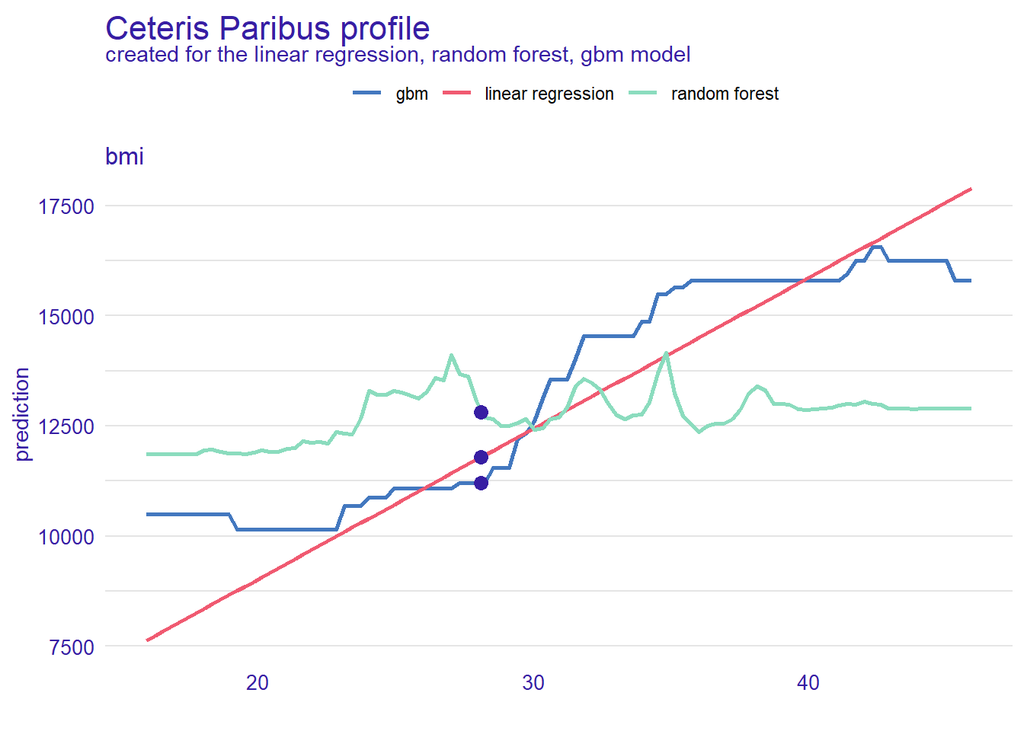

```r
plot(cp_lr, cp_rf, cp_gbm, variables = "bmi")
```

## `children` Variable

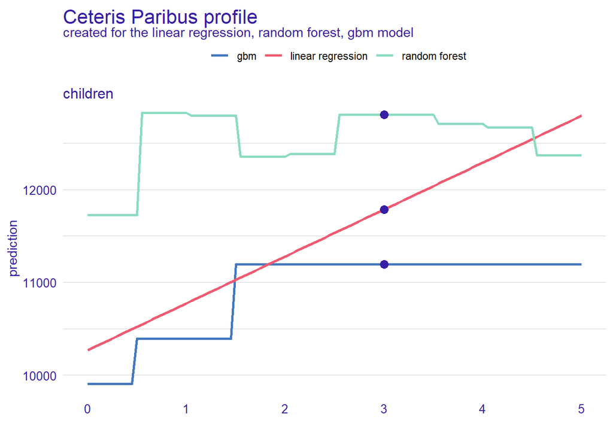

```r
plot(cp_lr, cp_rf, cp_gbm, variables = "children")
```

## `smoker` Variable

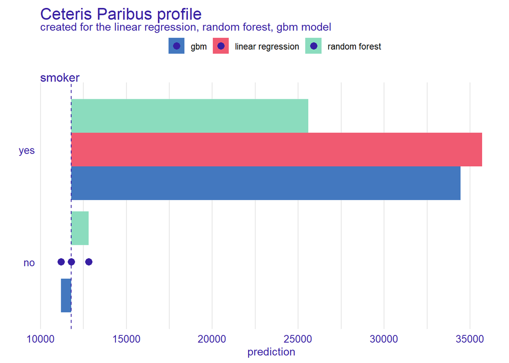

```r
plot(cp_lr, cp_rf, cp_gbm, variables = "smoker", variable_type = "categorical", categorical_type = "bars")
```

## `region` Variable

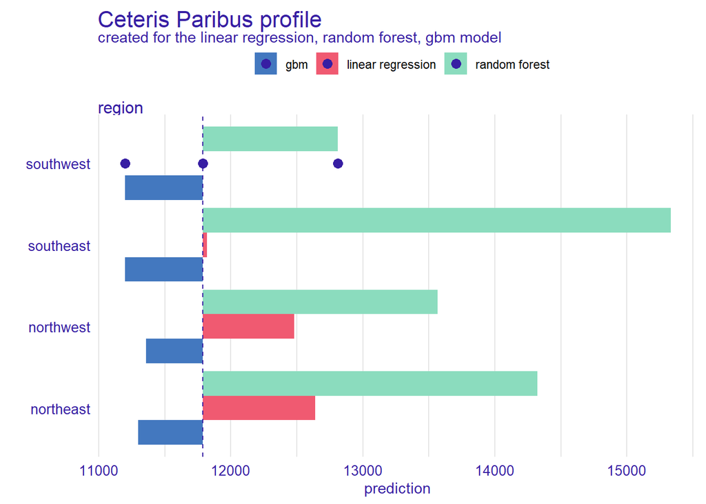

```r
plot(cp_lr, cp_rf, cp_gbm, variables = "region", variable_type = "categorical", categorical_type = "bars")
```

# 4. Models’ Ceteris Paribus Profiles Comparison

## `age` Variable

- predictions are similar values
- gbm’s predictions have the smallest values

## `bmi` Variable

- values of Random Forest’s prediction are close to each other and difference between values is the smallest among three models
- differences between predictions’ values for Linear Regression are the larges
- for gbm and Linear Regression with the increase of bmi comes increase in predicted values
- for Random Forest curve resembles constant function, with the highest values around 26-28 and 35

## `smoker` Variable

- for every model perdictions’ values are considerably higher if the value of `smoker` is “yes”
- similar results may be an effect of high importance of `smoker` variable in predictions, which was discover in previous homeworks

## `region` Variable

- for different models different regions have the biggest positive impact
- for Linear Regression value “southeast” has one of the smallest contribution
- for Random Forest the same value has the greatest positive contribution
- differences in effects could be larger because of low importance of this variable for prediction

# Conclusions